# Week 6 Worksheet

# Part 4: Prepare Data for models

1. Format the gene expression matrix to include subtype information:
- Firstly, transpose the matrix so genes are on the columns
- Using `merge()`, join the mat and metadate file by “row.names”
- remove the left over “Row.names” column, it should be the 1st or 2nd column.

```r
mat <- t(mat)

mat <- merge(meta,mat,by="row.names")

## remove the rownames column
rownames(mat) <- mat$Row.names
mat <- mat[,-c(1)]
head(mat)
```

[output not shown]

[output cut: 2360 more lines]

[output not shown]

2. split into training and test data (70% - 30% split)

```r
# get indices for 70% of the data set
intrain <- createDataPartition(y = mat$Subtype, p= 0.7)[[1]]

# seperate test and training sets
training <- mat[intrain,]
testing <- mat[-intrain,]
```

# Part 5: Choose models

1. use a KNN to train the model on the training dataset, Please output the metrics using the `draw_confusionmatrix()` function from stackoverflow.

```r
knnFit=knn3(x=training[,-1], # training set
            y=training$Subtype, # training set class labels
            k=2)
# predictions on the train set
trainPred=predict(knnFit,training[,-1], type="class")

confusionMatrix(data=training$Subtype,reference=trainPred)
```

```
## Confusion Matrix and Statistics
##
##           Reference
## Prediction Basal Her2
##      Basal   238   14
##      Her2      5  239
##
##                Accuracy : 0.9617
##                  95% CI : (0.9408, 0.9768)
##     No Information Rate : 0.5101
##     P-Value [Acc > NIR] : < 2e-16
##
##                   Kappa : 0.9234
##
##  Mcnemar's Test P-Value : 0.06646
##
##             Sensitivity : 0.9794
##             Specificity : 0.9447
##          Pos Pred Value : 0.9444
##          Neg Pred Value : 0.9795
##              Prevalence : 0.4899
##          Detection Rate : 0.4798
##    Detection Prevalence : 0.5081
##       Balanced Accuracy : 0.9620
##
##        'Positive' Class : Basal
##
```

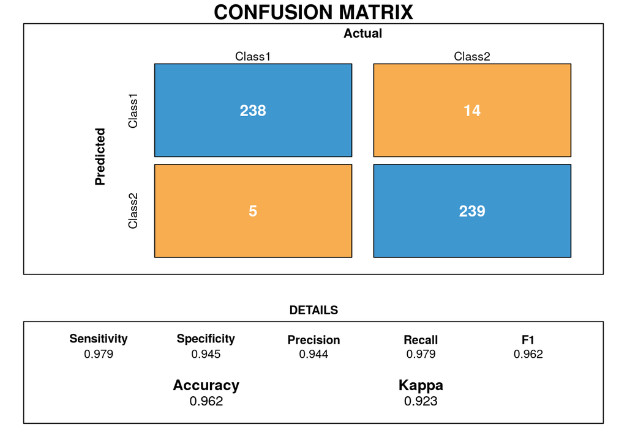

```r
cm <- confusionMatrix(data=training$Subtype, reference=trainPred)

draw_confusion_matrix <- function(cm) {

  layout(matrix(c(1,1,2)))
  par(mar=c(2,2,2,2))
  plot(c(100, 345), c(300, 450), type = "n", xlab="", ylab="", xaxt='n', yaxt='n')
  title('CONFUSION MATRIX', cex.main=2)

  # create the matrix
  rect(150, 430, 240, 370, col='#3F97D0')
  text(195, 435, 'Class1', cex=1.2)
  rect(250, 430, 340, 370, col='#F7AD50')
  text(295, 435, 'Class2', cex=1.2)
  text(125, 370, 'Predicted', cex=1.3, srt=90, font=2)
  text(245, 450, 'Actual', cex=1.3, font=2)
  rect(150, 305, 240, 365, col='#F7AD50')
  rect(250, 305, 340, 365, col='#3F97D0')
  text(140, 400, 'Class1', cex=1.2, srt=90)
  text(140, 335, 'Class2', cex=1.2, srt=90)

  # add in the cm results
  res <- as.numeric(cm$table)
  text(195, 400, res[1], cex=1.6, font=2, col='white')
  text(195, 335, res[2], cex=1.6, font=2, col='white')
  text(295, 400, res[3], cex=1.6, font=2, col='white')
  text(295, 335, res[4], cex=1.6, font=2, col='white')

  # add in the specifics
  plot(c(100, 0), c(100, 0), type = "n", xlab="", ylab="", main = "DETAILS", xaxt='n', yaxt='n')
  text(10, 85, names(cm$byClass[1]), cex=1.2, font=2)
  text(10, 70, round(as.numeric(cm$byClass[1]), 3), cex=1.2)
  text(30, 85, names(cm$byClass[2]), cex=1.2, font=2)
  text(30, 70, round(as.numeric(cm$byClass[2]), 3), cex=1.2)
  text(50, 85, names(cm$byClass[5]), cex=1.2, font=2)
  text(50, 70, round(as.numeric(cm$byClass[5]), 3), cex=1.2)
  text(70, 85, names(cm$byClass[6]), cex=1.2, font=2)
  text(70, 70, round(as.numeric(cm$byClass[6]), 3), cex=1.2)
  text(90, 85, names(cm$byClass[7]), cex=1.2, font=2)
  text(90, 70, round(as.numeric(cm$byClass[7]), 3), cex=1.2)

  # add in the accuracy information
  text(30, 35, names(cm$overall[1]), cex=1.5, font=2)
  text(30, 20, round(as.numeric(cm$overall[1]), 3), cex=1.4)
  text(70, 35, names(cm$overall[2]), cex=1.5, font=2)
  text(70, 20, round(as.numeric(cm$overall[2]), 3), cex=1.4)
}

draw_confusion_matrix(cm)
```

2. test the knn model on the testing data and plot metrics.

```r
# predictions on the test set, return class labels
testPred=predict(knnFit,testing[,-1],type="class")

# compare the predicted labels to real labels
# get different performance metrics
confusionMatrix(data=testing[,1],reference=testPred)
```

```
## Confusion Matrix and Statistics
##
##           Reference
## Prediction Basal Her2
##      Basal    98   10
##      Her2      8   96
##
##                Accuracy : 0.9151
##                  95% CI : (0.8691, 0.9489)
##     No Information Rate : 0.5
##     P-Value [Acc > NIR] : <2e-16
##
##                   Kappa : 0.8302
##
##  Mcnemar's Test P-Value : 0.8137
##
##             Sensitivity : 0.9245
##             Specificity : 0.9057
##          Pos Pred Value : 0.9074
##          Neg Pred Value : 0.9231
##              Prevalence : 0.5000
##          Detection Rate : 0.4623
##    Detection Prevalence : 0.5094
##       Balanced Accuracy : 0.9151
##
##        'Positive' Class : Basal
##
```

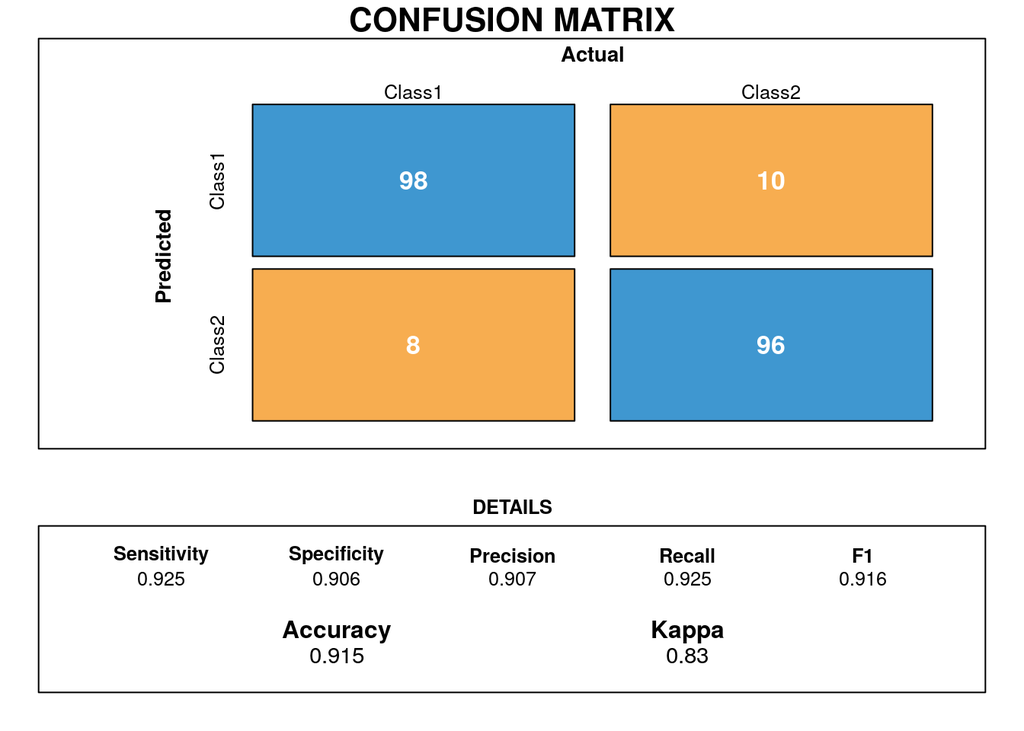

```r
cm1 <- confusionMatrix(data=testing[,1],reference=testPred)

draw_confusion_matrix(cm1)
```

3. use cross fold validation and a tuning grid to optimise a KNN model. Run on the training and tes data:

```r
trctrl <- trainControl(method = "cv",number=10)

knn_fit <- train(Subtype~., data = training,
                 method = "knn",
                 trControl=trctrl,
                 tuneGrid = data.frame(k=1:12))

trainPred=predict(knn_fit,training[,-1], type="raw")

confusionMatrix(data=training$Subtype,reference=trainPred)
```

```
## Confusion Matrix and Statistics
##
##           Reference
## Prediction Basal Her2
##      Basal   235   17
##      Her2      3  241
##
##                Accuracy : 0.9597
##                  95% CI : (0.9384, 0.9752)
##     No Information Rate : 0.5202
##     P-Value [Acc > NIR] : < 2e-16
##
##                   Kappa : 0.9194
##
##  Mcnemar's Test P-Value : 0.00365
##
##             Sensitivity : 0.9874
##             Specificity : 0.9341
##          Pos Pred Value : 0.9325
##          Neg Pred Value : 0.9877
##              Prevalence : 0.4798
##          Detection Rate : 0.4738
##    Detection Prevalence : 0.5081
##       Balanced Accuracy : 0.9608
##
##        'Positive' Class : Basal
##
```

[figure not shown]

```r
draw_confusion_matrix(cm)
```

```r
testPred=predict(knn_fit,testing[,-1],type="raw")

confusionMatrix(data=testing[,1],reference=testPred)
```

```
## Confusion Matrix and Statistics
##
##           Reference
## Prediction Basal Her2
##      Basal    95   13
##      Her2      1  103
##
##                Accuracy : 0.934
##                  95% CI : (0.8917, 0.9634)
##     No Information Rate : 0.5472
##     P-Value [Acc > NIR] : < 2.2e-16
##
##                   Kappa : 0.8682
##
##  Mcnemar's Test P-Value : 0.003283
##
##             Sensitivity : 0.9896
##             Specificity : 0.8879
##          Pos Pred Value : 0.8796
##          Neg Pred Value : 0.9904
##              Prevalence : 0.4528
##          Detection Rate : 0.4481
##    Detection Prevalence : 0.5094
##       Balanced Accuracy : 0.9388
##
##        'Positive' Class : Basal
##
```

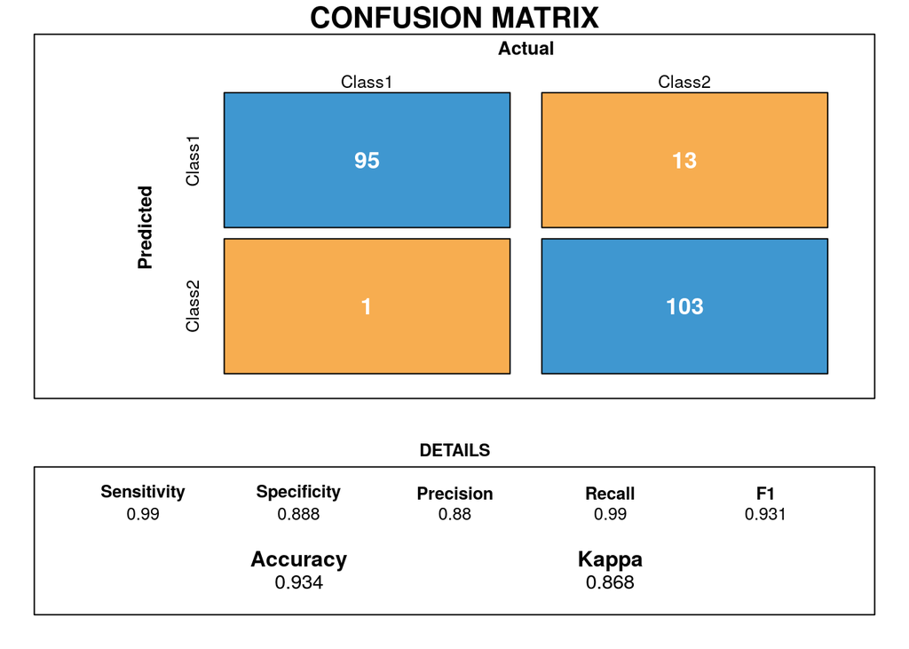

```r
cm1 <- confusionMatrix(data=testing[,1],reference=testPred)

draw_confusion_matrix(cm1)
```

4. Use an Elastic net model on the training and test data. Use cross fold validation and a tuning grid for optimal values for lambda and alpha.

```r
elnFit <- train(Subtype~., data = training,
                method = "glmnet",
                trControl = trainControl("cv", number = 10),
                # alpha and lambda paramters to try
                 tuneGrid = data.frame(alpha=seq(0.1,0.7,0.05),
                                       lambda=seq(0.1,0.7,0.05)))
# Best tuning parameter
elnFit$bestTune
```

```
##   alpha lambda
## 1   0.1    0.1
```

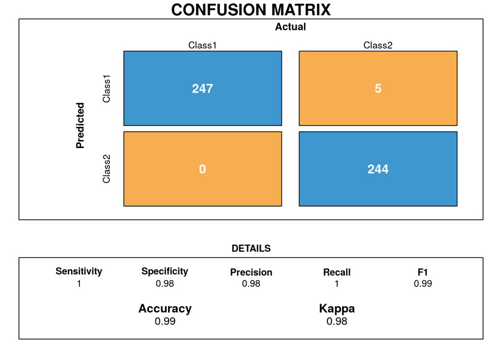

```r
train_pred=predict(elnFit,training[,-1], type="raw")
cm <- confusionMatrix(training[,1], reference = train_pred)

test_pred=predict(elnFit,testing[,-1], type="raw")
cm1 <- confusionMatrix(testing[,1],reference = test_pred)


draw_confusion_matrix(cm)
```

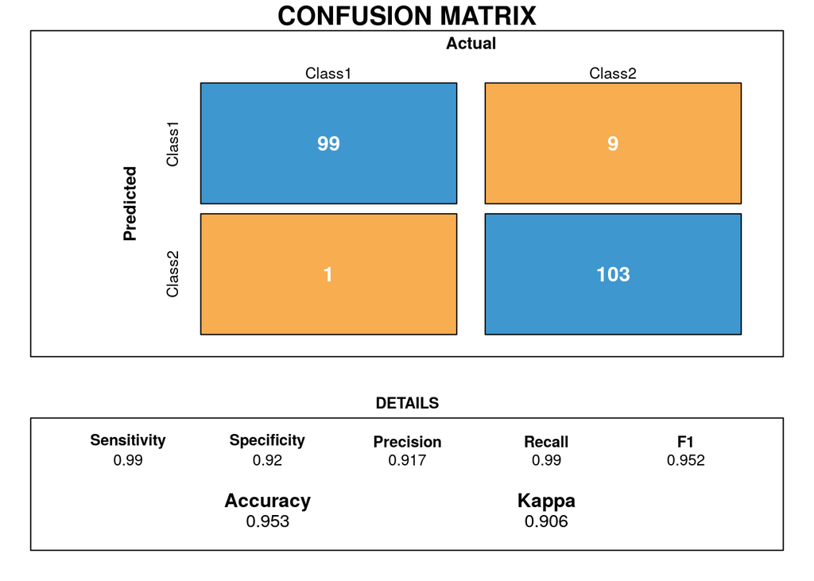

```r
draw_confusion_matrix(cm1)
```

5. Use a Random Forest model on the training and test data. Use cross fold validation in the model.

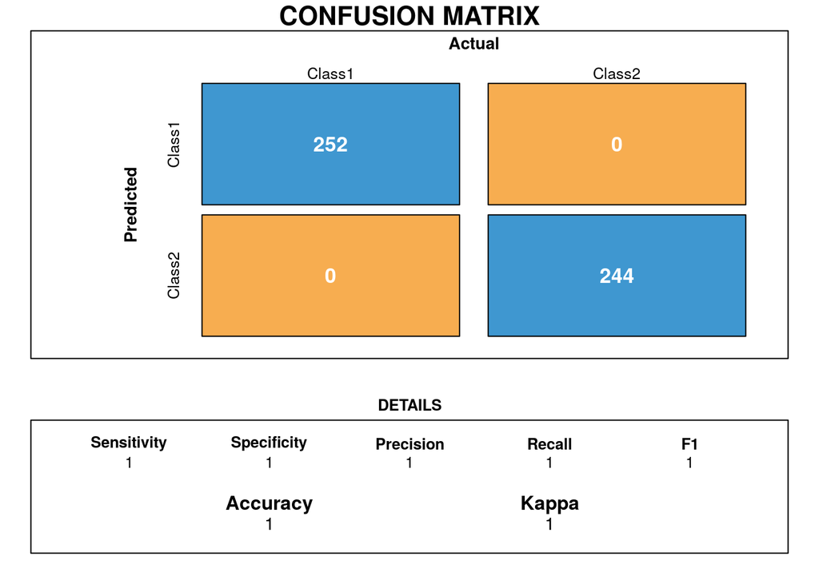

```r
trctrl <- trainControl(method = "cv",number=10)

# we will now train random forest model
rfFit <- train(Subtype~.,
               data = training,
               method = "ranger",
               trControl=trctrl,
               importance="permutation", # calculate importance
               tuneGrid = data.frame(mtry=100,
                                     min.node.size = 1,
                                     splitrule="gini"))

trainPred=predict(rfFit,training[,-1])

cm <- confusionMatrix(data=training$Subtype,reference=trainPred)

# predictions on the test set, return class labels
testPred=predict(rfFit,testing[,-1])

# compare the predicted labels to real labels
# get different performance metrics
cm1 <- confusionMatrix(data=testing[,1],reference=testPred)

draw_confusion_matrix(cm)
```

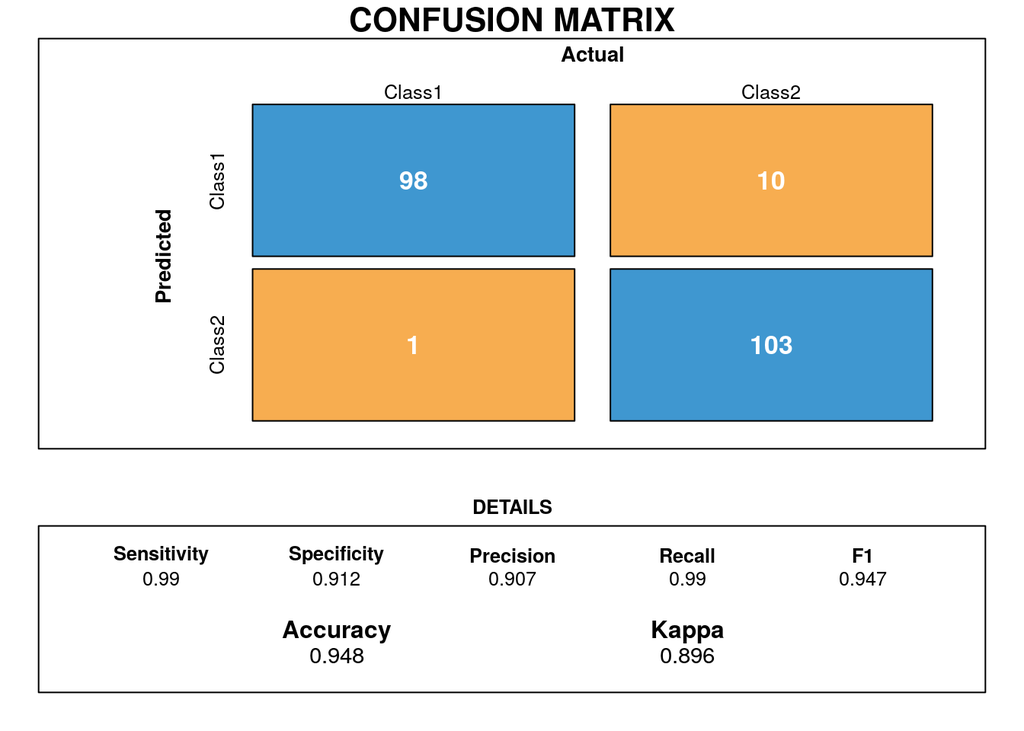

```r
draw_confusion_matrix(cm1)
```

6. *bonus* look up the documentation for carets `resamples()` function (hint: F1 to view help, specifically at the very bottom of the page). Use `dotplot()` on the `resamps` variable you made.

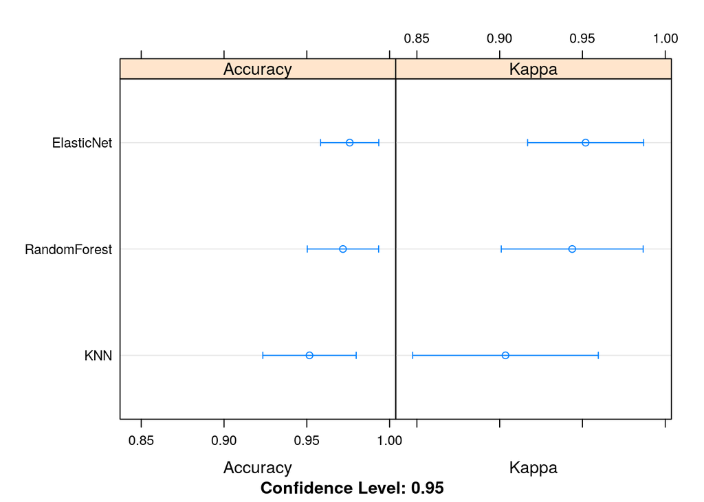

```r
resamps <- resamples(list(RandomForest = rfFit,
                          ElasticNet = elnFit,
                          KNN = knn_fit))

dotplot(resamps)
```